# Script cleaning Standard Deviation

Eric Ménétré

14 mai 2019

The aim of this function is to clean data by removing the extreme values according to a deviation from the mean. usually, extreme values above 2 or 2.5 SD are removed from the analysis. Removing extreme values can be a very long and tedious job, and automation could be useful. The following function does it automatically for you.

## Let us imagine the following dataframe:

Nottice that the data frame should be in a tidy format (i.e. at least a column for values and a groupping variable)

```r
library(reshape2)
data.test.1 <- rnorm(50, mean = 500, sd = 200)
data.test.2 <- rnorm(50, mean = 600, sd = 200)
data.test.3 <- rnorm(50, mean = 400, sd = 200)
data.test.4 <- rnorm(50, mean = 800, sd = 200)
data.test.5 <- rnorm(50, mean = 550, sd = 200)
data.test.6 <- rnorm(50, mean = 530, sd = 200)
df.test <- data.frame(data.test.1, data.test.2, data.test.3, data.test.4, data.test.5, data.test.6)
df.test.bon <- melt(df.test)
head(df.test.bon)
```

```
##      variable    value
## 1 data.test.1 525.4247
## 2 data.test.1 371.5856
## 3 data.test.1 730.9034
## 4 data.test.1 596.4462
## 5 data.test.1 662.6720
## 6 data.test.1 313.0374
```

## Now execute the following function:

```r
clean.sd <- function(df.var.val, df.var.group, n.sd, data, fill) {

  plot.before.cleaning <<- qqnorm(df.var.val, main = "Distribution before cleaning") ; qqline(df.var.val)

  # Création d'un data frame avec les limites inférieures et supérieures
  moy.df.test <- data.frame(aggregate(df.var.val, list(df.var.group), mean, na.rm = TRUE))
  sd.df.test <- data.frame(aggregate(df.var.val, list(df.var.group), sd, na.rm = TRUE))
  lim.df.test <- moy.df.test
  lim.df.test$sd <- sd.df.test$x
  lim.df.test$lim.inf <- lim.df.test$x - (n.sd*lim.df.test$sd)
  lim.df.test$lim.sup <- lim.df.test$x + (n.sd*lim.df.test$sd)
  print("Means, standard deviations, inferior and superior limits of the data:")
  print(lim.df.test)

  # Nettoyage des données

  for (i in 1:nrow(lim.df.test)) {
    for (j in 1:nrow(data)) {
      if (is.na(df.var.val[i])) {
        next
      } else if (lim.df.test$Group.1[i] == df.var.group[j]) {
        if (df.var.val[j] <= lim.df.test$lim.inf[i]) {
          df.var.val[j] <- fill
        } else if (df.var.val[j] >= lim.df.test$lim.sup[i]) {
          df.var.val[j] <- fill
        }
      }
    }
  }

  clean.val <<- df.var.val

  # Vérification du succès de l'opération
    # Définition du nombre de valeurs au dessus ou en dessous de la limite pour le premier sujet

  sum.lim.sup <<- sum(df.var.val[df.var.val == lim.df.test$Group.1[1]] >= lim.df.test$lim.sup[1], na.rm = TRUE) + sum(df.var.val[df.var.val == lim.df.test$Group.1[2]] >= lim.df.test$lim.sup[2], na.rm = TRUE)
  sum.lim.inf <<- sum(df.var.val[df.var.val == lim.df.test$Group.1[1]] <= lim.df.test$lim.inf[1], na.rm = TRUE) + sum(df.var.val[df.var.val == lim.df.test$Group.1[2]] <= lim.df.test$lim.inf[2], na.rm = TRUE)
  sum.lim.tot <<- sum(sum.lim.sup, sum.lim.inf)

  if (sum.lim.tot == 0) {
    print("The job is done and work was verified for the first 2 groups")
  } else if (sum.lim.tot != 0) {
    print("WARNING: BE CAREFUL, SOME EXTREME VALUES REMAIN AT LEAST IN THE FIRST 2 GROUPS")
  }

  plot.after.cleaning <<- qqnorm(df.var.val, main = "Distribution after cleaning") ; qqline(df.var.val)
  plot.before.cleaning
  plot.after.cleaning

}
```

## This function does several operations :

- It creates a table containing the mean value, the SD and the inferior and superior limits according to a certain number of SD above the mean (the number of standard deviation above the mean is customizable)
- It replaces the values either under the inferior limit or above the superior limit in a temporay vector that will be needed to be added to the original data frame. The replacement values can be defined in the function
- It verifies for the first two groups that none of the extreme values are still present in the output vector
- it creates two qqplots with the qqlines to display the values distribution before and after cleaning

## The arguments of the functions are:

```
clean.sd (df.var.val = , df.var.group = , n.sd = , data = , fill = )
```

- df.var.val = variable from the original data frame containing all the values
- df.var.group = variable from the original data frame containing all the names of the different condition needed to be cleaned separately
- n.sd = number of standard deviations above and under the mean needed to be removed
- data = name of the original data frame
- fill = value to replace the extreme values

## Example with the dataframe defined above:

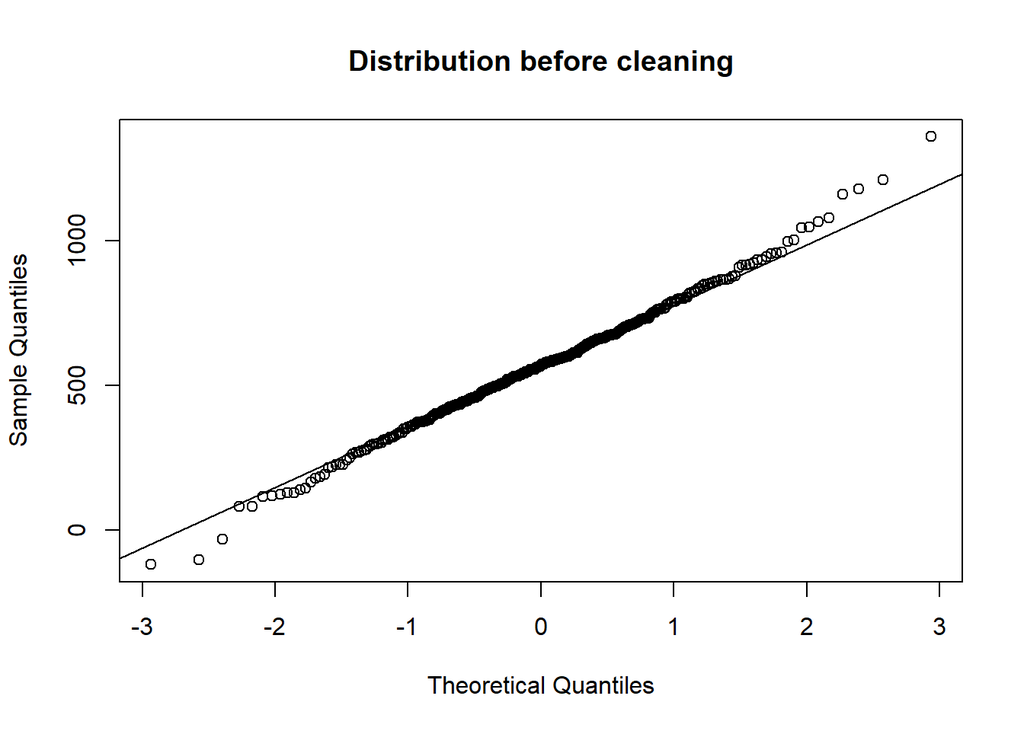

```
## [1] "Means, standard deviations, inferior and superior limits of the data:"
##       Group.1        x       sd   lim.inf   lim.sup
## 1 data.test.1 541.6398 200.3284 140.98293  942.2967
## 2 data.test.2 582.1534 176.9281 228.29718  936.0096
## 3 data.test.3 401.5665 184.2340  33.09846  770.0346
## 4 data.test.4 772.9227 213.0437 346.83522 1199.0102
## 5 data.test.5 518.1766 192.8824 132.41182  903.9415
## 6 data.test.6 588.7032 225.2456 138.21196 1039.1945
## [1] "The job is done and work was verified for the first 2 groups"
```

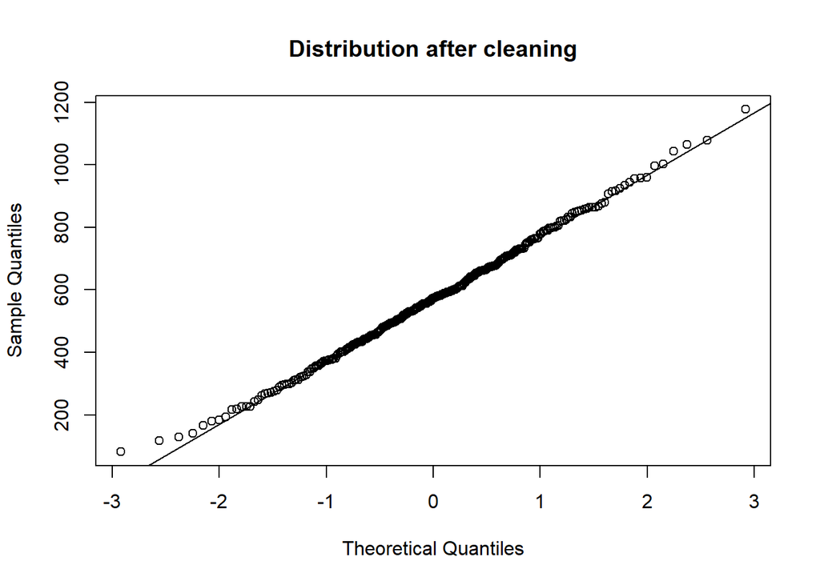

[output not shown]

[output cut: 98 more lines]

```r
clean.sd(df.var.val = df.test.bon$value, df.var.group = df.test.bon$variable, n.sd = 2, data = df.test.bon, fill = NA)
```

After execution of the function, sevral elements were created in the Global Environment. The most important output is the values called “clean.val”

Now to integrate this new vector to the original dataframe, use the following argument:

```r
df.test.bon$clean.val <- clean.val
head(df.test.bon, 40)
```

```
##       variable     value clean.val
## 1  data.test.1 525.42471  525.4247
## 2  data.test.1 371.58559  371.5856
## 3  data.test.1 730.90343  730.9034
## 4  data.test.1 596.44621  596.4462
## 5  data.test.1 662.67202  662.6720
## 6  data.test.1 313.03741  313.0374
## 7  data.test.1 578.09745  578.0974
## 8  data.test.1 492.88290  492.8829
## 9  data.test.1 320.26688  320.2669
## 10 data.test.1 780.36488  780.3649
## 11 data.test.1 447.21183  447.2118
## 12 data.test.1 726.69576  726.6958
## 13 data.test.1 605.49169  605.4917
## 14 data.test.1 832.39953  832.3995
```

[output cut: 26 more lines]

## Summary

After executing the command, many things appear. In the plot window, two qqplots are now displayed (use the left arrow above the plot window to see the previous one). In the environement many variables were created and more importantly a vector containing all the cleaned values was created. In the console, a table containing the groups, mean, standard deviations and the inferior and superior limits used to mark rows as NA is displayed. The console should also return either the sentence : “The job is done and work was verified for the first 2 groups” or “WARNING: BE CAREFUL, SOME EXTREME VALUES REMAIN AT LEAST IN THE FIRST 2 GROUPS”. If the second cas appears, start crying or come to complain ;-). Finally, the cleaned values should appear in the console (sometimes twice…).

If perhaps a cleaning according to different factors is needed (e.g. within the age groups and within the subjects), then run twice the function by changing the argument df.var.group.

There will probably be cases in which the function wil crash. In so, do not hesitate to come back to me for bug report and updates of the function.